# Computer Simulations STAT2005

## Felix Chan

### School of Economics and Finance

## Welcome

- Overview of the unit
- Some motivating examples (the fun stuff)
- Some revisions on basic probability and statistics (it has been a long holidays)

## (Administrative) Overview

- Two hours lecture and two hours workshop (weekly).
- A case study due in the middle of the semester.
- A project to be presented by the end of the year.
- No examination (yay!)

## Overview (cont.)

- Programming languages R and Python (your choice)
- RStudio/Rmarkdown or Jupyter notebooks (your choice)
- Whenever possible we will cover both R and Python but some workshops will only focus on one or the other.
- Textbook is based on R but the code can be easily translated into Python
- It does mean you will need to have some working knowledge on both

## Overview (Teaching staff)

Lecturers:

```
- Felix Chan, School of Economics and Finance
- Aloke Phatak, Department of Mathematics and Statistics
- Ritu Gupa, Department of Mathematics and Statistics
- Artur L.,
```

Additional Guest Instructors (Workshop):

```
- Andrew Rohl
- Artur L.,
```

## Motivation

- This unit introduces some basic concepts and techniques in Computer Simulations
- why?
- Powerful computers at low cost means computation is now "cheap"
- This allows us to visualise complex systems in specific cases very efficiently.

[figure not shown]

## Example 1 (Logistic map)

Consider the following difference equation:

$$ y_t = Ay_{t-1} \left ( 1- y_{t-1} \right )$$

where $A \in (0,4]$.

We usually concern with the behaviour of $y_t$ when $t$ gets large. Two important questions here

1. How does $y_t$ behave with different $A$?
2. How does $y_t$ behave with different initial values ($y_0$)?

```python
def our_diff_eq(N,A,y0):
    """
    Simulate the difference equation :math:' y_t = Ay_{t-1} \left ( 1- y_{t-1} \right )'
    Inputs:
        N: int. The number of observations we wish to generate.
        A: double in (0,4]. The parameter in the difference equation.
        y0: double. The starting point of the difference equation.
    Output:
        y: (N,) numpy array.
    """
    y = np.zeros(N)
    y[0] = y0
    for t in np.arange(1,N):
        y[t] = A*y[t-1]*(1-y[t-1])
    return y
```

```python
%%R
our_diff_eq <- function(N,A,y0) {
    y <- c(y0)
    for (t in 2:N) {
        y[t] <- A*y[t-1]*(1-y[t-1])
    }
    return(y)
}
```

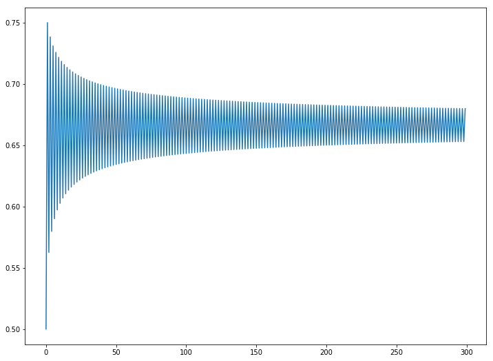

```python
N=300
A = 3
y0 = 0.5
y = our_diff_eq(N,A,y0)
plt.plot(y)
```

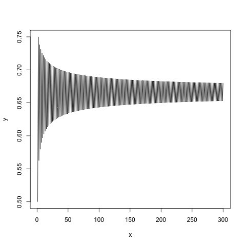

```python
%%R
N <- 300
A <- 3
y0 <- 0.5
y <- our_diff_eq(N,A,y0)
plot(y,type="l", xlab="x")
```

Perhaps we can do two columns after all...

## Example 1 (Logistic Map Cont.)

- Let's see if we can answer the first question. How does $y_t$ behave with different values of $A$?
- One way to do this, is to call *our_diff_eq* function over different values of $A$.
- We can then summarise the outputs as an animation.

```python
ani
```

[video not shown]

## Example 1 (Logistic Map Cont.)

- As $A$ approaches 4, $y_t$ becomes more and more erratic!!
- Note that there is no noise (stochastic component) in the equation. Yet it seems to be generating something that looks "random".
- You may get to play with this a little more in the workshop.

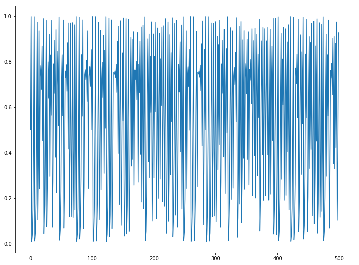

```python
A=3.99
N=500
y = our_diff_eq(N,A,y0)
plt.plot(y)
```

## Review of Probability and Statistics

### Sets

- $\emptyset$ denotes empty set.
- $\Omega$ is often used to denote a set of all possible outcomes, *sample space*.
- An *event* is any subset of $\Omega$.
- $A$\ $B = \{x: x\in A \text{ and } x \not \in B\}$
- $A\cup B = \{x: x\in A \text{ or } x \in B\}$, the union operator.
- $A\cap B = \{x: x \in A \text{ and } x \in B\}$, the intersection operator.
- $\bar{A} = \Omega$\ $A$, the complement of $A$. Sometimes we use $A^c$.

### Probability axioms

- $\mathbb{P} (\Omega) = 1$.
- $\mathbb{P} (A) > 0$.
- $\mathbb{P} \left ( \sum^\infty_{i=1} A_i \right ) = \sum^\infty_{i=1} \mathbb{P} (A_i)$ if $A_i$ are disjoint sets, i.e. $A_i \cap A_j =\emptyset$ for $i\neq j$.

### Probability axioms

From the axioms we should be able to prove the following (quite easily)

- $\mathbb{P} (\emptyset) = 0 $.
- $\mathbb{P} \left (\bar{A} \right ) = 1 - \mathbb{P} (A)$.
- $\mathbb{P} (A) < \mathbb{P} (B)$ if $A \subset B$.
- $\mathbb{P} \left (A \cup B \right ) = \mathbb{P} (A) + \mathbb{P} (B) - \mathbb{P} \left ( A \cap B \right )$.